# simon-5501-10-slides

## Topics to be covered

- What you will learn
  - The analysis of variance model
  - The F-test
  - Assumptions
  - Confidence intervals
  - R code for analysis of variance
  - Sample size justification
  - R code for sample size justification

## Review two-sample t-test

- $H_0:\ \mu_1=\mu_2$
- $H_1:\ \mu_1 \ne \mu_2$
- $T=\frac{\bar X_1-\bar X_2}{se}$
  - Accept H0 if T is close to zero.

## What to do with three or more groups?

- Analysis of variance test framework
  - $H_0:\ \mu_1=\mu_2=...=\mu_k$
  - $H_1:\ \mu_i \ne \mu_j$ for some i, j
  - Accept H0 if the F ratio (defined below) is close to 1.
- The alternative is NOT $H_0:\ \mu_1 \ne \mu_2 \ne ...\ne \mu_k$
  - Some equalities might be mixed in
  - Example: $\mu_1=\mu_2$, but $\mu_1 \ne \mu3$ and $\mu2 \ne \mu3$.

## Artificial data

```
# A tibble: 11 × 2
   g         y
   <chr> <dbl>
 1 A        23
 2 A        30
 3 A        25
 4 B        33
 5 B        36
 6 B        41
 7 B        37
 8 B        43
 9 C        24
10 C        29
11 C        31
```

## Scatterplot

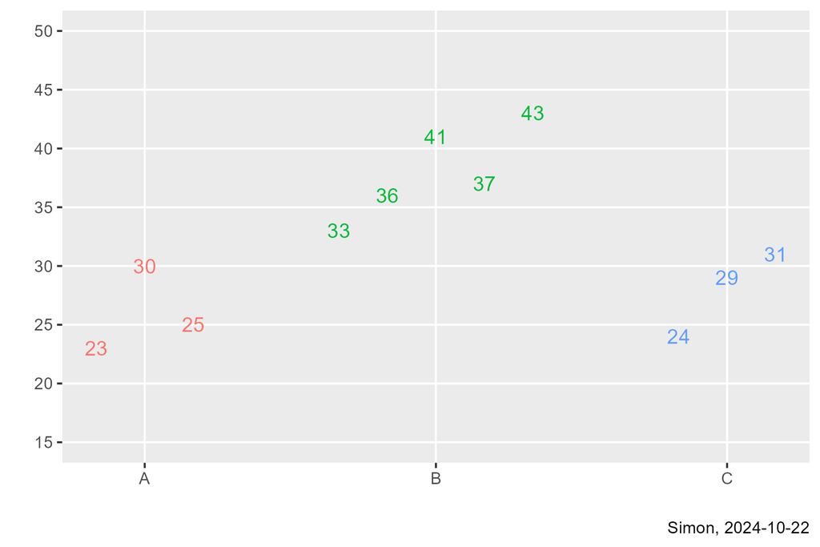

## SS(Total) or SST = 452

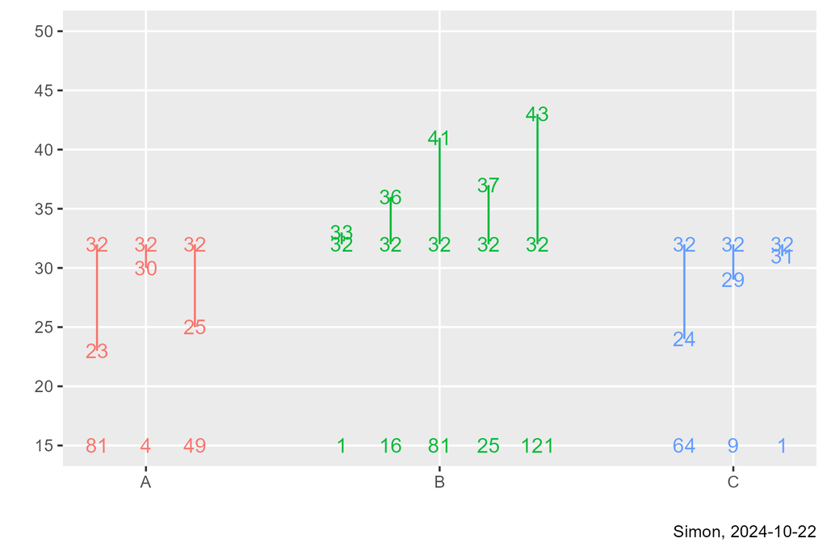

## SS(Within) or SSW = 116

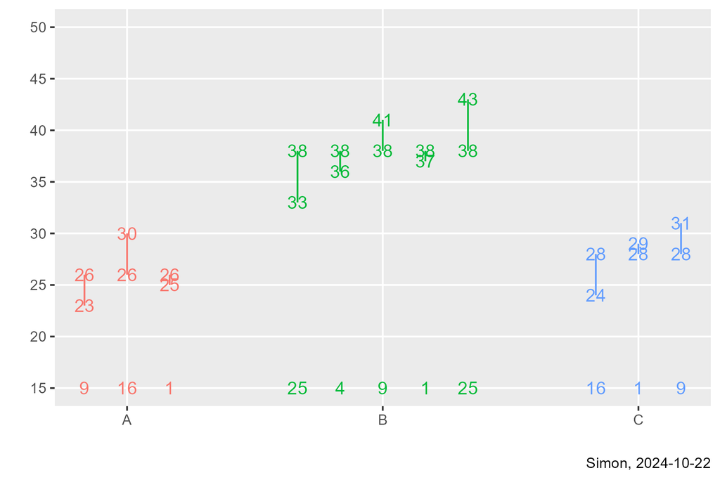

## SS(Between) or SSB = 336

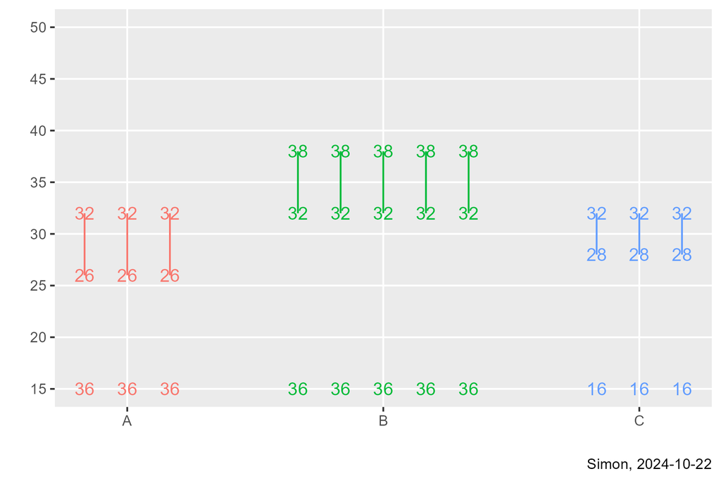

## Interpretation

- SST is the total variation in the dataset.
- SSE is the unexplained variation in the dataset
- SSB is the explained variation in the dataset
  - $R^2=\frac{SSB}{SST}$ is the proportion of explained variation

## Other names for the sum of squares

- SSW is sometimes abbreviated as SSE or SSR
- SSB is sometimes abbreviated as SSR(!)

## Degrees of freedom

- For SS(Total), df = 10
- For SS(Within), df = 8
- For SS(Between), df = 2
- In general,
  - n = number of observations total
  - k = number of groups
    - Total df = n-1
    - Within df = n-k
    - Between df = k-1

## R calculations of sums of squares

```
       term df sumsq meansq
1 factor(g)  2   336  168.0
2 Residuals  8   116   14.5
```

## Break #1

- What you have learned
  - The analysis of variance model
- What’s coming next
  - The F-test

## The F-distribution

- Ratio of two measures of variation
- Two measures are comparable if F is close to 1
- F distribution is skewed and can never be negative
- Two measures of degrees of freedom
  - $df_1$ = degrees of freedom for numerator
  - $df_2$ = degrees of freedom for denominator

## Graph of the F distribution

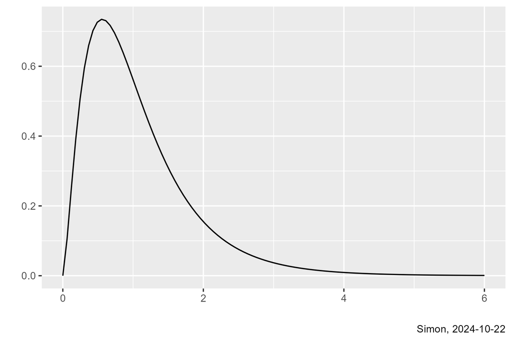

## The F-test

- $H_0:\ \mu_1=\mu_2=...=\mu_k$
- $H_1:\ \mu_i \ne \mu_j$ for some i, j
  - Compute F = MS(Between) / MS(Within)
  - Accept H0 if the F < $F(1-\alpha, k-1, N-k)$
- Only reject $H_0$ for large values
  - Note: the f-ratio can never be negative

## The p-value for the F test

- p-value = P[F(k-1, N-k) > F]
- Accept $H_0$ if p-value > $\alpha$.

## Can you use analysis of variance when you have two groups?

- Yes
  - $F = T^2$
- Some prefer the t-test with two groups
  - Simpler
- Some prefer analysis of variance
  - Generalizes to more complex settings (risk adjustment, interactions)

## How does analysis of variance compare to the analysis of variance table in linear regression

- Linear regression SSR is comparable to analysis of variance SSB
  - Both represent explained variation
- Linear regression SSE is comparable to analysis of variance SSE
  - Both represent unexplained variation

## R code for the F test

```
       term df sumsq meansq statistic     p.value
1 factor(g)  2   336  168.0  11.58621 0.004337887
2 Residuals  8   116   14.5        NA          NA
```

## R-squared

- $R^2 = \frac{SS(Between)}{SS(Total)}$
  - Proportion of variation explained by groups

```
     logLik      AIC      BIC deviance nobs r.squared
1 -28.56465 65.12929 66.72087      116   11 0.7433628
```

## Break #2

- What you have learned
  - The F-test
- What’s coming next
  - Assumptions

## Population model

- There are k populations
  - $Y_{11}, Y_{12}, .\ \ .\ \ ., Y_{1N_1}$
  - $Y_{21}, Y_{22}, ..., Y_{2N_2}$
  - …
  - $Y_{k1}, Y_{k2}, .\ .\ ., Y_{kN_k}$

## Sampling from the population

- Select k samples
  - $Y_{11}, Y_{12}, .\ .\ ., Y_{1n_1}$
  - $Y_{21}, Y_{22}, ..., Y_{2n_2}$
  - …
  - $Y_{k1}, Y_{k2}, .\ \ .\ \ ., Y_{kn_k}$

## Assumptions about the populations

- $Y_{ij} = \mu_i + \epsilon_{ij}$
  - $\epsilon_{ij}$ should be
    - Normal
    - Homogenous (equal variance)
    - Independent

## Residuals in analysis of variance

- In linear regression
  - $e_i=Y_i-\hat{Y}_i$
  - Residual = Observed - Predicted
- In analysis of variance
  - $e_{ij}=Y_{ij}-\bar{Y}_i$
  - Residual = Observed - Predicted
- Behavior of $e_{ij}$ hints at assumptions on $\epsilon_{ij}$

## Important caveats

- Important notes
  - Check normality only in the residuals
  - Non-normality is less of a concern for large sample sizes
  - Unequal sample sizes is not a violation of assumptions

## Influential data points

- Less emphasis in analysis of variance
  - Impossible to have an outlier in the independent variable when it is categorical
- Studentized residuals may still be worth examining.

## How to check for non-normality

- Boxplots
  - Look for evidence of skewness or outliers

## How to check for heterogeneity

- Boxplots
  - Look for one box that is much wider than another
- Descriptive statistics
  - Look for one standard deviation much larger than another

## How to check for independence

- Qualitative assessment of how data was collected

## Optional: analysis of residuals

- Normal probability plot (QQ plot) of residuals
- Histogram of residuals
- Plot predicted values versus residuals.

## Break #3

- What you have learned
  - Assumptions
- What’s coming next
  - Confidence intervals

## Multiple comparisons issue

- Type I error: rejecting the null hypothesis when the null hypothesis is true.
  - Multiple simultaneous hypotheses increase the Type I error rate.
- $E_1$ = Type I error for Hypothesis 1
- $E_2$ = Type I error for Hypothesis 2
  - $P[E_1\ \cup\ E_2]=P[E_1]+P[E_2]-P[E_1\ \cap\ E_2]$
  - $P[E_1\ \cup\ E_2]\ \le\ P[E_1]+P[E_2]$
  - $P[E_1\ \cup\ E_2]\ \le\ 2 \alpha$

## Bonferroni adjustment

- For m hypotheses
  - $P[E_1\ \cup\ ...\ \cup E_m]\ \le\ m \alpha$
- Test each hypothesis at $\alpha/m$
  - Preserves overall Type I error rate
- Example, 3 simultaneous hypotheses
  - Reject H0 if p-value < 0.05/3 or 0.0167

## Tukey post hoc tests

- $H1\ \mu_i \ne \mu_j$ for at least one i, j
- If you reject H0, which i,j comparisons are unequal?
  - With k groups, there are k(k-1)/2 comparisons
- Studentized range (Tukey test)
  - Requires equal sample sizes per group
  - Uses harmonic mean approximation for slightly unequal sample sizes.
    - Do not use harmonic means if seriously different sample sizes.
- `TukeyHSD`

## Tukey post hoc test for k=3

- $H_1:\ \mu_i \ne \mu_j$ for some i, j
- There are 3 sub-hypotheses
  - $H_{1a}:\ \mu_1 \ne \mu_2$ and/or
  - $H_{1b}:\ \mu_1 \ne \mu_3$ and/or
  - $H_{1c}:\ \mu_2 \ne \mu_3$
    - Does the confidence interval exclude zero
    - Is the adjusted p-value less than alpha?

## Tukey post hoc test for k=4

- $H_1:\ \mu_i \ne \mu_j$ for some i, j
- There are 6 sub-hypotheses
  - $H_{1a}:\ \mu_1 \ne \mu_2$
  - $H_{1b}:\ \mu_1 \ne \mu_3$
  - $H_{1c}:\ \mu_1 \ne \mu_4$
  - $H_{1d}:\ \mu_2 \ne \mu_3$
  - $H_{1e}:\ \mu_2 \ne \mu_4$
  - $H_{1f}:\ \mu_3 \ne \mu_4$

## Alternatives to Tukey post hoc tests, 1

- Bonferroni adjustment
  - Works for unequal sample sizes per group
  - Works for unequal variances
- Dunnett’s test
  - Multiple treatments versus a single control
- Scheffe’s test
  - Works for complex comparison
    - Example $\mu_1\ vs.\ \frac{\mu_2+\mu_3+\mu_4}{3}$

## Controversies over Tukey/Bonferroni adjustment

- Criticisms that extend beyond one factor analysis of variance.
- Increases Type II errors
- Impractical for large values of m

## Ambiguities in Tukey post hoc test results

- One possible outcome
  - Conclude that $\mu_1\ =\ \mu_2$
  - Conclude that $\mu_2\ =\ \mu_3$
  - Conclude that $\mu_1\ \ne\ \mu_3$

## Geography analogy

[figure not shown]

## Break #4

- What you have learned
  - Confidence intervals
- What’s coming next
  - R code for analysis of variance

## Live demonstration, part 1

The following demonstration uses the wolf-river-pollution dataset. Refer to the [data dictionary](https://github.com/pmean/data/blob/main/files/wolf-river-pollution.yaml) found on my github site.

You can also find the [R code](https://github.com/pmean/classes/blob/master/biostats-1/10/src/simon-5501-10-demo.qmd) on my github site.

## Break #5

- What you have learned
  - R code for analysis of variance
- What’s coming next
  - Sample size justification

## Using the power.anova.test function to estimate sample size

- *power.anova.test*
  - *groups* is the number of groups
  - *n* is the number of observations per group
  - *between.var* is the estimate of MSB
  - *within.var* is the estimate of MSE
  - *sig.level* is the alpha level
  - *power* is the power
- Set *n=NULL* to estimate sample size

## What if n is outside your budget?

- Increase between.var
- Increase Type I error rate (sig.level)
- Increase Type II error rate (decrease power)
- Decrease number of groups

## Break #6

- What you have learned
  - Sample size justification
- What’s coming next
  - R code for sample size justification

## Live demonstration, part 2

This is a continuation of simon-5501-10-demo.

## Break #7

- What you have learned
  - R code for sample size justification
- What’s coming next
  - Your homework

## Your homework

The programming assignment is available through Canvas, but it actually links to [a page on my github site](https://github.com/pmean/classes/blob/master/biostats-1/10/src/simon-5501-10-directions.md).

## Summary

- What you have learned
  - The analysis of variance model
  - The F-test
  - Assumptions
  - Confidence intervals
  - R code for analysis of variance
  - Sample size justification
  - R code for sample size justification
  - Your homework